# Challenge B

Audrey Pujol et Yann Cecconi

30 novembre 2017

https://github.com/AudreyPujol/ChallengeB-Yann-Cecconi-Audrey-Puj ol

# Task 1B - Predicting house prices in Ames, Iowa

## Step 1

Random Forest is an ensemble learning (both classification and regression) technique. It is one of the commonly used predictive modelling and machine learning technique.

Key advantages of using Random Forest

- Reduce chances of over-fitting
- Higher model performance or accuracy

## Step 2

In order to train random forest on the training data, we first deal with the missing values of the corresponding data frame.

Then, we test the randomForest code on the model that we created in Challenge A ( based on the training data) :

```r
randomForest ( SalePrice ~ LotArea + LotShape + LandContour + Condition2 + OverallQual
               + OverallCond + PoolArea + KitchenQual + LotConfig
               + Neighborhood+RoofMatl
          + MasVnrArea + ExterQual + BsmtQual +  BsmtExposure + BsmtFinType1
          +  BsmtFinSF1 + BsmtFinSF2 + BsmtUnfSF + X1stFlrSF +  X2ndFlrSF, data=train)
```

```
##
## Call:
##  randomForest(formula = SalePrice ~ LotArea + LotShape + LandContour +      Condition2 + OverallQual + OverallCond + PoolArea + KitchenQual +      LotConfig + Neighborhood + RoofMatl + MasVnrArea + ExterQual +      BsmtQual + BsmtExposure + BsmtFinType1 + BsmtFinSF1 + BsmtFinSF2 +      BsmtUnfSF …
##                Type of random forest: regression
##                      Number of trees: 500
## No. of variables tried at each split: 7
##
##           Mean of squared residuals: 911341671
##                     % Var explained: 85.35
```

## Step 3

First we make predictions on the test data.

Then we make predictions on the linear regression of our choice.

Comments :

# Task 2B - Predicting house prices in Ames, Iowa

## Step 1

To estimate a low-flexibility local linear model on the training data, we use the command npreg

## Step 2

To estimate a high-flexibility local linear model on the training data, we use the command npreg

## Step 3

Here, we plot the scatterplot of x-y along with the corresponding predictions (on the training data) using the ggplot command.

```
## # A tibble: 122 x 6
##              y          x       y.true which.data y.ll.lowflex
##          <dbl>      <dbl>        <dbl>      <chr>        <dbl>
##  1  0.20433883 -0.6264538 -0.245848275   training -0.200217871
##  2 -0.01236649  0.1836433  0.006193347   training  0.182352673
##  3  3.13050121  1.5952808  4.059863355   training  3.023714572
##  4 -1.45168388  0.3295078  0.035776429   training  0.236226060
##  5 -1.62750566 -0.8204684 -0.552313364   training -0.425804071
##  6  1.11583565  0.4874291  0.115806846   training  0.310101940
##  7 -0.21878864  0.7383247  0.402478052   training  0.498338173
##  8 -1.19354142  0.5757814  0.190885432   training  0.363540869
##  9  1.84080947 -0.3053884 -0.028481152   training  0.007813978
## 10 -0.17939960  0.3898432  0.059247498   training  0.261909431
## # ... with 112 more rows, and 1 more variables: y.ll.highflex <dbl>
```

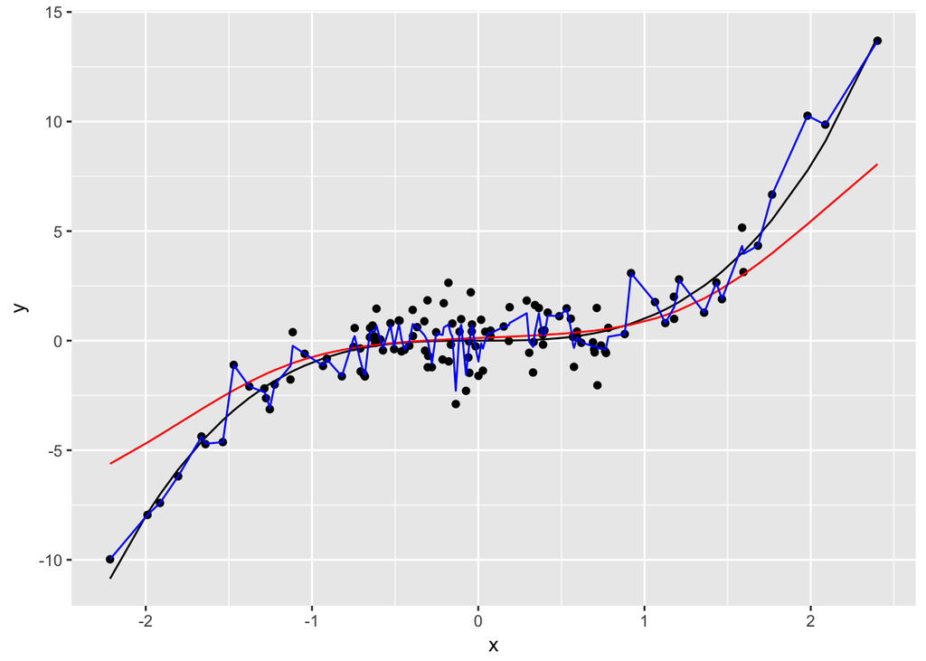

## Step4

According to the previous graph, the more variable predictions are the ones generated by the high-flexibility local linear model.

## Step 5

```
## # A tibble: 28 x 6
##             y          x       y.true which.data y.ll.lowflex
##         <dbl>      <dbl>        <dbl>      <chr>        <dbl>
##  1 -0.9015671 -0.8356286 -0.583498718       test  -0.44815580
##  2  3.8802495  1.5117812  3.455149104       test   2.60289580
##  3  0.8187215 -0.6212406 -0.239761502       test  -0.19548025
##  4 -0.5837001  0.9438362  0.840794584       test   0.77420576
##  5  0.4094355  0.8212212  0.553835065       test   0.59241185
##  6  0.9008803  1.1000254  1.331092102       test   1.09962838
##  7  0.6575602  1.4330237  2.942795753       test   2.23958632
##  8  0.5076451 -0.1350546 -0.002463362       test   0.07595184
##  9 10.2105426  2.1726117 10.255251705       test   6.57995968
## 10 -1.6257013  0.4755095  0.107517132       test   0.30368108
## # ... with 18 more rows, and 1 more variables: y.ll.highflex <dbl>
```

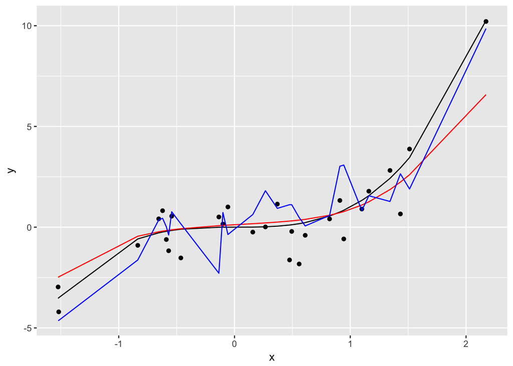

The more variable predictions are still the ones generated by the high-flexibility local linear model. But now, they are a little bit less changeable.

## Step 6

```r
bw <- seq(0.01, 0.5, by = 0.001)
```

## Step 7

```r
llbw.fit <- lapply(X = bw, FUN = function(bw) {npreg(y ~ x, data = training, method = "ll", bws = bw)})
```

## Step 8

To compute the MSE on the training data, we compute the predicted values and then the mean squares of the difference between the current Y values and the predictions.

```r
mse.training <- function(fit.model){
  predictions <- predict(object = fit.model, newdata = training)
  training %>% mutate(squared.error = (y - predictions)^2) %>% summarize(mse = mean(squared.error))
}
mse.train.results <- unlist(lapply(X = llbw.fit, FUN = mse.training))
```

## Step 9

```r
mse.test <- function(fit.model){
  predictions <- predict(object = fit.model, newdata = test)
  test %>% mutate(squared.error = (y - predictions)^2) %>% summarize(mse = mean(squared.error))
}
mse.test.results <- unlist(lapply(X = llbw.fit, FUN = mse.test))
```

## Step 10

```
## # A tibble: 491 x 3
##    bandwidth mse.train mse.test
##        <dbl>     <dbl>    <dbl>
##  1     0.010 0.3460818 2.257278
##  2     0.011 0.3708529 2.189654
##  3     0.012 0.3947976 2.126863
##  4     0.013 0.4181274 2.071231
##  5     0.014 0.4408973 2.023309
##  6     0.015 0.4630605 1.982573
##  7     0.016 0.4845110 1.947912
##  8     0.017 0.5051165 1.917947
##  9     0.018 0.5247438 1.891276
## 10     0.019 0.5432788 1.866645
## # ... with 481 more rows
```

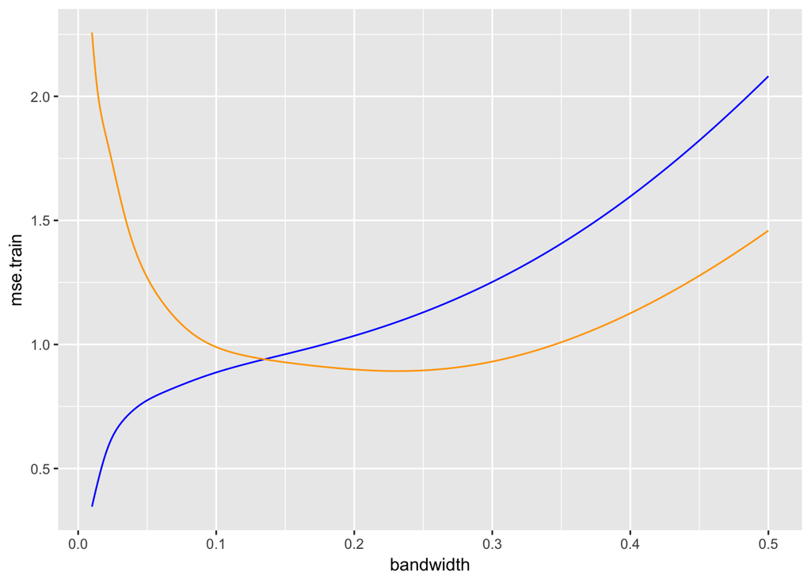

# Task 3B - Privacy Regulation compliance in France

## Step 1

```r
cnil<- read.csv2(file="~/rprog/OpenCNIL_Organismes_avec_CIL_VD_20171115.csv")
departement<- read.csv(file="~/rprog/departement.csv")
```

## Step 2

First we create a new variable in the CNIL dataset by selecting the first two digits of the postcode from the CNIL dataset. The table function allows us to create a new data frame with the new variable and the frequency (number of organizations that has nominated a CNIL per department). Then, we clean it.